# Retail_sales_prediction

# Dependence of MarkDown2 and MarDown3 on Holiday :

It is seen that there is a positive correlation between holiday weekends and markdown 2 and 3. There is positive correlation between the size of the store and the MarkDown 1, 4 and 4 There is a positive correlation between size of the store and the weekly sales. However, it may be a systematic correlation as there are many employees needs to be worked for a larger store. There is a marginal positive correlation between the fuel price and MarkDown 1 but all other MarkDowns are negatively correlated with fuel price. Temperature of the region is mostly anticorrelated with the MarkDowns and no correlation between weekly sales CPI and unemployment are marginally anticorrelated with MarkDowns and no correlation between weekly sales

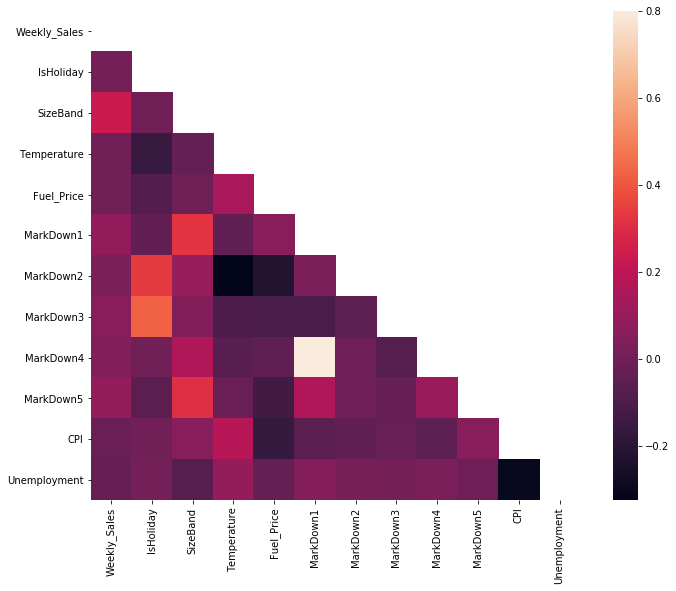

```python
#correlation matrix
f, ax = pl.subplots(figsize=(12, 9))
sns.heatmap(df_features.drop(['Store', 'Dept'], axis=1).corr(), mask=mask, vmax=.8, square=True);
```

# How the type of stores have correlation:

Similar conclusions for A and B type of stores can be derived. There are slight difference between these conclusion and C type stores

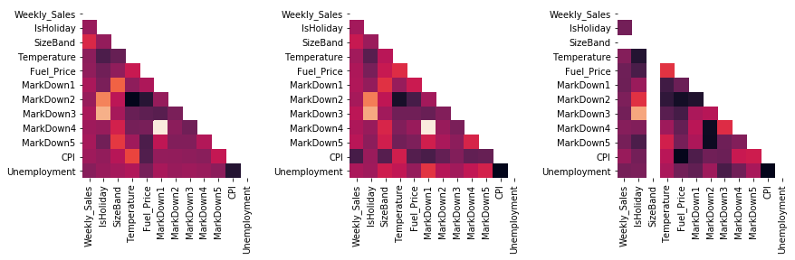

```python
#correlation matrix
fig, axarr = pl.subplots(1,3, figsize=(15, 3.5))
sns.heatmap(df_features.drop(['Store', 'Dept'], axis=1)[df_features.Type == 'A'].corr(), mask=mask, vmax=.6,
            square=True, ax=axarr[0], cbar=None);
sns.heatmap(df_features.drop(['Store', 'Dept'], axis=1)[df_features.Type == 'B'].corr(), mask=mask, vmax=.6,
            square=True, ax=axarr[1], cbar=None);
sns.heatmap(df_features.drop(['Store', 'Dept'], axis=1)[df_features.Type == 'C'].corr(), mask=mask, vmax=.6,
            square=True, ax=axarr[2], cbar=None);
```

```python
from sklearn.ensemble import RandomForestRegressor
from sklearn.model_selection import train_test_split
def mape(y_true, y_pred):
    ABS = np.abs(y_true - y_pred)
    return (ABS.sum()/y_true.sum()) * 100
seed = 123
model = RandomForestRegressor(n_estimators=20, criterion='mse', bootstrap=True, n_jobs=-1, random_state=seed)
X_train,X_test,Y_train,Y_test=train_test_split(X,Y,test_size=0.2)
model.fit(X_train, y_train)
y_pred = model.predict(X_test)
100-mape(np.expm1(X_test), np.expm1(y_pred))
```

[output not shown]